# PHILLY TREE INVENTORY

BMIN503/EPID600 Final Project

Author

Saiido

## 1 Overview

For my final project, Ill be examining tree cover using data collected annually by the city of Philadelphia. The goal is to explore how tree inventory is existing in this location, given the significant direct health implications as well as the increasing frequency of weather events due to ongoing climate change. This dataset is available through the city of Philadelphia on Open Data Philly.

## 2 Introduction

This study aims to investigate the urban tree inventory in Philadelphia, Pennsylvania, with the overarching goal of understanding the differential benefits that trees provide in urban environments. With the ongoing escalation of climate change, there is an increasing need to comprehend urban tree inventories. This urgency is fueled by the more frequent and severe weather occurrences. Trees in urban locations serve as carbon sinks, effectively reducing greenhouse gas emissions, in addition to their aesthetic appeal and temperature cooling properties. Moreover, the significance of trees in enhancing public health cannot be emphasized enough. Trees enhance respiratory health due to their proficiency in removing pollutants from the air. Moreover, research has found urban areas that possess a significant abundance of greenness, including trees, are linked to a better state of mental well-being and reduced levels of stress. Furthermore, fluctuations in tree cover significantly affect the ability of the surrounding ecosystem to withstand challenges, the long-term survivability of urban environments, and the overall health and wellness of city goers. The interaction between environmental and health concerns underscores the need of comprehending the extent of tree cover in urban regions.

This topic goes beyond simple environmental concern; its multidisciplinary nature becomes clear when considering the several fields that collaborate on this topic. Interactions with University of Pennsylvania staff have revealed that this analysis values input from urban planning, environmental science, public health, and climate studies. The importance of urban planning lies in its ability to analyze how city architecture and expansion impact the distribution and number of trees. Environmental science offers insights into the ecological variables that impact the long-term persistance of urban trees, specifically in terms of their health and growth. Public health extends this examination by discussing the impact of tree cover on the air quality and health of those in the area. Finally, climate studies also demonstrate the significant impact of climate change on the distribution and ability of urban trees to withstand or recover from adverse conditions, such as urban heat islands.

The objective of this study is to perform a thorough analysis of the current tree inventory in Philadelphia, which is regularly updated on a yearly basis. The importance of this study resides in its implications for the well-being of the general population and the increased frequency of extreme weather caused by the ongoing difficulties of climate change. The dataset’s freely available to access and download through Open Data Philly.

## 3 Methods

As mentioned in the introduction, this analysis utilizes the tree inventory complied by the City of Philadelphia containing information on trees, consisting of: species, diameter at breast height (DBH) in inches, year of data collection, and geographic coordinates (longitude and latitude). To begin the exploratory analysis, I first visualized the distribution of key variables. Next, I generated maps via API key to display the spatial distribution of trees across the city, delineated by census-tract county lines of Philadelphia. I additionally created a map plotting trees, categorized into four groups based on their diameter: poles (0-9.9 inches), small (10-19.9 inches), medium (20-29.9 inches), and large to giant (30 inches and above); these are following the guidelines provided by the Forest Service at the U.S. Department of Agriculture (USDA). To analyze the statistical significance of my findings, I conducted an ANOVA and Pearson correlation tests.

Below is the R code used to retrieve and clean the data, as well as perform the analysis:

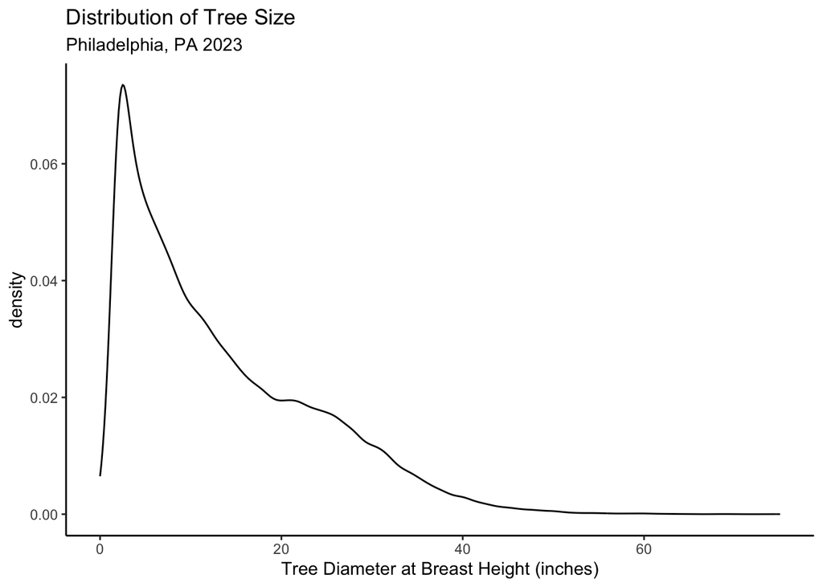

```r
setwd('/Users/noors/Desktop/UPENN/BiomedicalDataScience/Final/Noor_BMIN503_Final_Project')
library(readr)
library(magrittr)
library(dplyr)
library(ggplot2)
library(car)
library(tidyverse)
library(sf)
library(tigris)
library(tidycensus)
library(leaflet)
library(RColorBrewer)
library(ggmap)
library(ggpubr)
library(forcats)
library(broom)
options(tigris_use_cache = TRUE)
options(progress_enabled = FALSE)

ppr_tree_inventory_2023 <- read_csv("ppr_tree_inventory_2023.csv")
#View(ppr_tree_inventory_2023)

trees <- ppr_tree_inventory_2023 |>
  filter(tree_name != "NA") |> #remove any trees that aren't named
  filter(tree_name != "UNKNOWN UNKNOWN - UNKNOWN") |>#remove unknown names
  filter(tree_dbh != "NA") |> #remove any NA in breast diam
  filter(tree_dbh != -3) |> #remove negative breast diam
  filter(tree_dbh != 0) #remove NA breast diam

names<-unique(ppr_tree_inventory_2023$tree_name) #showing list of type of trees
clean_names<-unique(trees$tree_name) #making sure NA is gone

ggplot(trees, aes(x = tree_dbh)) + #checking distribution of data, we see that it is skewed right but not an issues since n>30
  geom_density() +
  theme_classic() +
  xlim(0,75)+ #set x-axis interval
  labs(x = "Tree Diameter at Breast Height (inches)", title = "Distribution of Tree Size", subtitle = "Philadelphia, PA 2023")
```

```r
tree_diameters <- trees %>%
  group_by(tree_name) %>%
  summarize(avg_diameter = mean(tree_dbh, na.rm = TRUE)) #creating new tibble to find average dbh of each tree

tree_freq <- trees %>%
  group_by(tree_name) %>%
  summarize(tree_freq = n()) #creating new tibble to count freq of tree in dataset


#frequency of trees by name and that tree's average dbh, would help focus on planting these trees
treename_and_freq <- left_join(tree_diameters, tree_freq, by = "tree_name") #joining tree count & diam
hightreename_and_freq<- treename_and_freq %>%   arrange(desc(tree_freq), desc(avg_diameter))
head(hightreename_and_freq)
```

```
# A tibble: 6 × 3
  tree_name                                avg_diameter tree_freq
  <chr>                                           <dbl>     <int>
1 PLATANUS X ACERIFOLIA - LONDON PLANETREE        24.8      16649
2 ACER RUBRUM - RED MAPLE                         11.4      10404
3 PRUNUS SPECIES - OTHER CHERRY                    8.27      7665
4 PYRUS CALLERYANA - CALLERY PEAR                 11.3       7370
5 GLEDITSIA TRIACANTHOS - HONEYLOCUST              8.39      5028
6 QUERCUS RUBRA - NORTHERN RED OAK                22.5       4989
```

```r
lowtreename_and_freq<- treename_and_freq
head(lowtreename_and_freq)
```

```
# A tibble: 6 × 3
  tree_name                        avg_diameter tree_freq
  <chr>                                   <dbl>     <int>
1 ABIES BALSAMEA - BALSAM FIR             12.4          5
2 ABIES FRASERI - FRASER FIR              15            1
3 ABIES SPECIES - OTHER FIR               17.6         10
4 ACER BUERGERANUM - TRIDENT MAPLE         4.81       339
5 ACER CAMPESTRE - HEDGE MAPLE             7.73      2476
6 ACER GINNALA - AMUR MAPLE                6.26       574
```

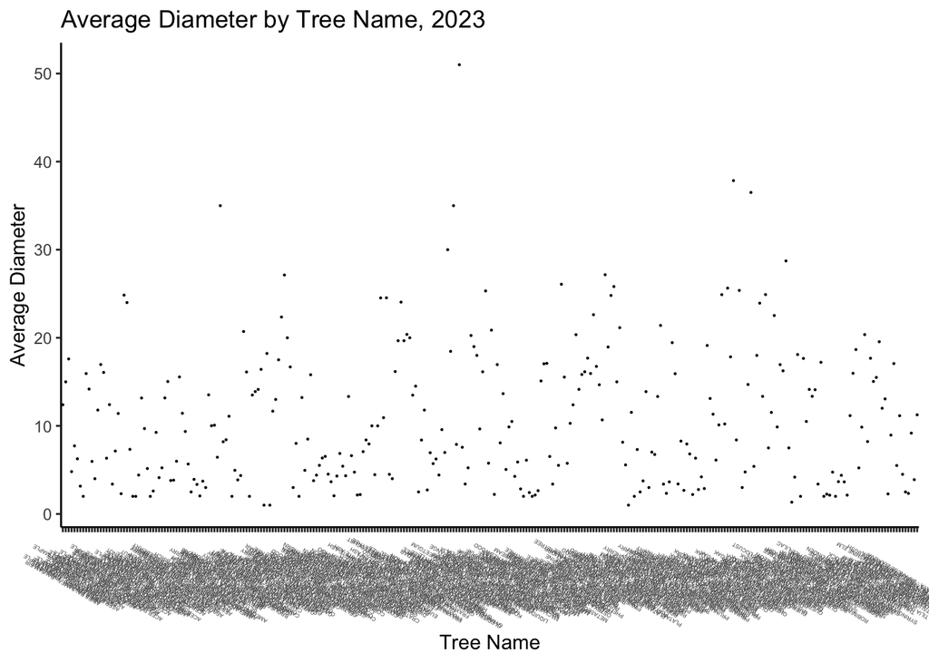

```r
ggplot(tree_diameters, aes(x = tree_name, y = avg_diameter)) +
  geom_point(size=0.1) +
  labs(title = "Average Diameter by Tree Name, 2023",
       x = "Tree Name",
       y = "Average Diameter") +
  theme_classic()+
  theme(axis.text.x = element_text(size = 3, angle = 150, vjust = 0.5, hjust=0.5)) #scatter plot to visualize theaverage diameter for each tree type, not helpful visual
```

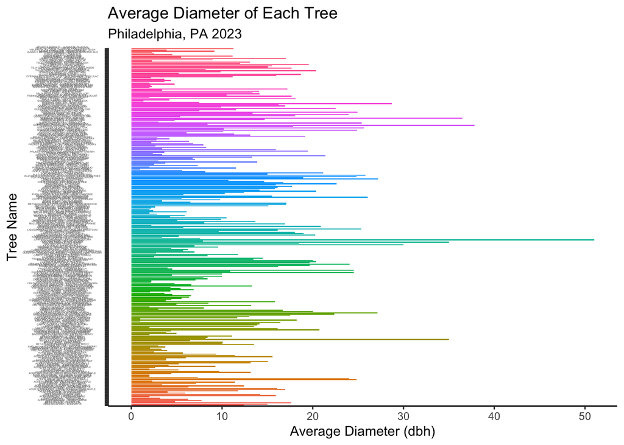

```r
ggplot(tree_diameters, aes(y = tree_name, x = avg_diameter, fill = tree_name)) +
  geom_col() +  # Using geom_col() for bar plot
  labs(title = "Average Diameter of Each Tree",
       y = "Tree Name",
       x = "Average Diameter (dbh)",
       subtitle = "Philadelphia, PA 2023") +
  theme_classic() +
  guides(fill = FALSE) +
  theme(axis.text.y = element_text(size = 2, vjust = -0.5, hjust=0.5)) #bar plot of trees and their avg diam
```

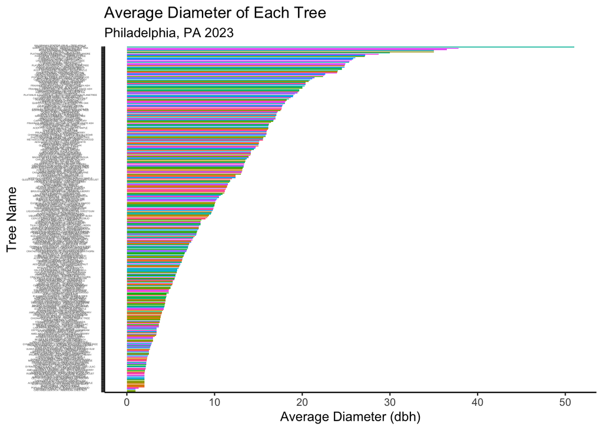

```r
ggplot(tree_diameters, aes(y = fct_reorder(tree_name, avg_diameter), x = avg_diameter, fill = tree_name)) +
  geom_col() +  # Using geom_col() for bar plot
  labs(title = "Average Diameter of Each Tree",
       y = "Tree Name",
       x = "Average Diameter (dbh)",
       subtitle = "Philadelphia, PA 2023") +
  theme_classic() +
  guides(fill = FALSE) +
  theme(axis.text.y = element_text(size = 2, vjust = -0.5, hjust = 0.5)) #trees in order of diam
```

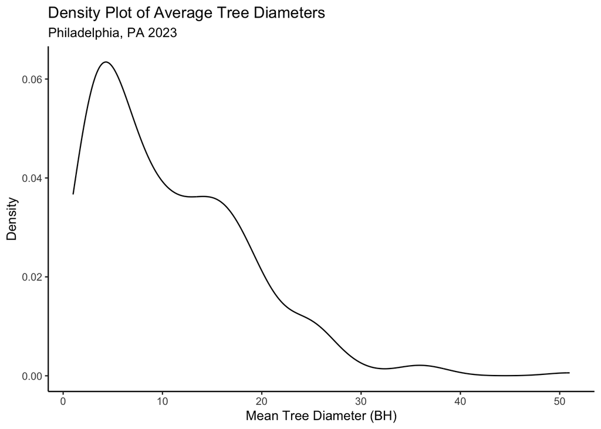

```r
ggplot(tree_diameters, aes(x = avg_diameter)) +
  geom_density() +
  theme_classic()+
  labs(x = "Mean Tree Diameter (BH)", y = "Density", title = "Density Plot of Average Tree Diameters", subtitle = "Philadelphia, PA 2023") #checking distribution of data
```

```r
stats1 <- aov(tree_dbh ~ tree_name, data = trees) # Perform ANOVA testing sig of tree names and their diam
summary(stats1)
```

```
                Df   Sum Sq Mean Sq F value Pr(>F)
tree_name      293  7201968   24580   340.4 <2e-16 ***
Residuals   149787 10815966      72
---
Signif. codes:  0 '***' 0.001 '**' 0.01 '*' 0.05 '.' 0.1 ' ' 1
```

```r
tuk <- TukeyHSD(stats1) #Perform Tukey Test show differences between names
tuk_output <- tidy(tuk) #make it tibble
head(tuk_output)
```

```
# A tibble: 6 × 7
  term      contrast          null.value estimate conf.low conf.high adj.p.value
  <chr>     <chr>                  <dbl>    <dbl>    <dbl>     <dbl>       <dbl>
1 tree_name ABIES FRASERI - …          0     2.60    -41.6     46.8         1
2 tree_name ABIES SPECIES - …          0     5.20    -16.9     27.3         1
3 tree_name ACER BUERGERANUM…          0    -7.59    -25.8     10.6         1
4 tree_name ACER CAMPESTRE -…          0    -4.67    -22.7     13.4         1
5 tree_name ACER GINNALA - A…          0    -6.14    -24.3     12.0         1
6 tree_name ACER GRISEUM - P…          0    -9.24    -27.4      8.87        1.00
```

```r
philly.tracts.2021 <- tracts("PA", "Philadelphia") #loads spatial data for Philadelphia as defined by census
st_write(philly.tracts.2021, "philly_tracts_2020.shp", #write spatial data to a shapefile.
         append = FALSE)
```

```
Deleting layer `philly_tracts_2020' using driver `ESRI Shapefile'
Writing layer `philly_tracts_2020' to data source
  `philly_tracts_2020.shp' using driver `ESRI Shapefile'
Writing 408 features with 12 fields and geometry type Multi Polygon.
```

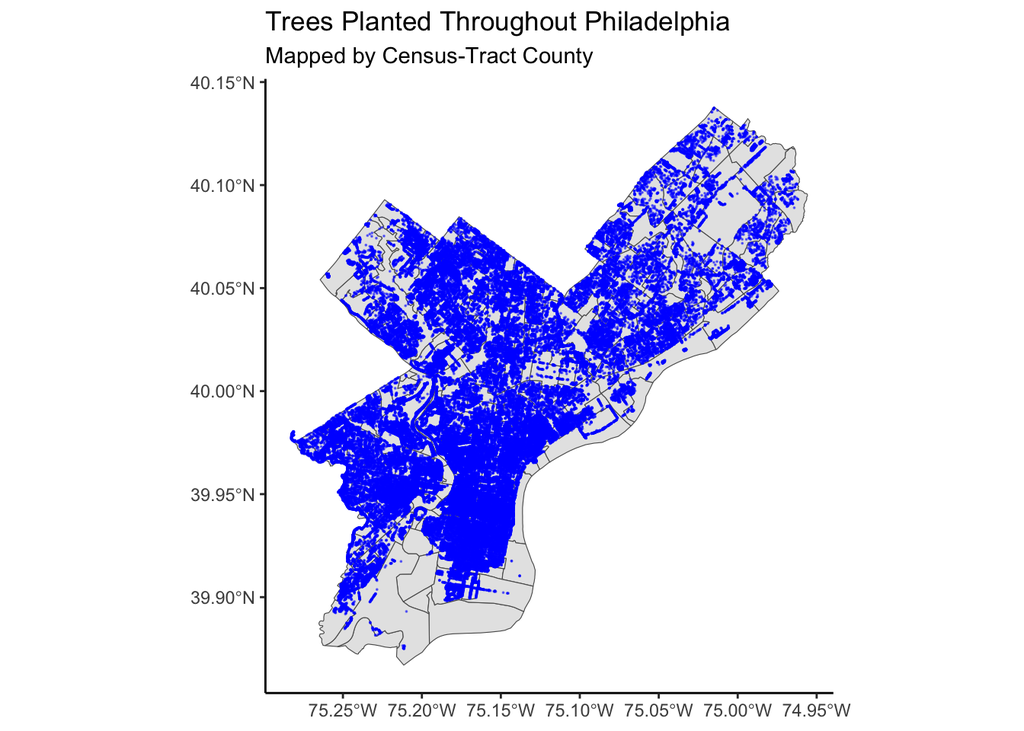

```r
phl.tri.sf <- st_as_sf(trees, coords = c("loc_x", "loc_y"), crs = 4326) #converts the data stored in trees to sf object
phl.tri.sf <- st_transform(phl.tri.sf, crs = st_crs(philly.tracts.2021)) #transforms the CRS of the phl.tri.sf to match the CRS of the philly.tracts.2020

joined_data <- st_join(phl.tri.sf, philly.tracts.2021, #spatial join between census info and trees info
                       join = st_intersects)

ggplot() +  # map all trees in Philly

  geom_sf(data = philly.tracts.2021) + #county outline
  geom_sf(data = phl.tri.sf,color = "blue", alpha = 0.5,  size = 0.000001)+ #long and lat of trees
  theme_classic() +
  labs(title = "Trees Planted Throughout Philadelphia", subtitle = "Mapped by Census-Tract County")
```

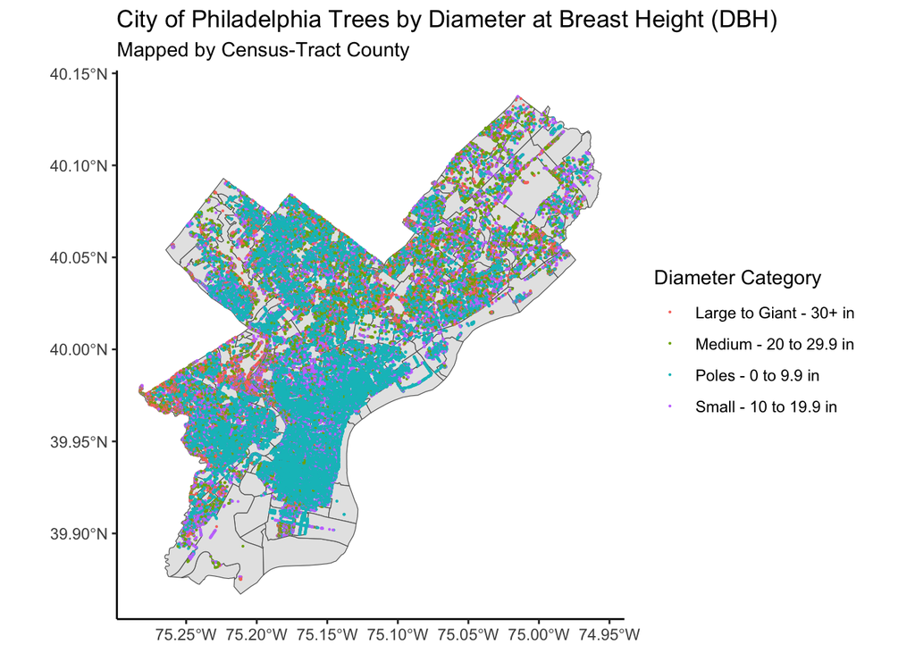

```r
joined_data<- joined_data %>% #creating categories for diameters
  mutate(dbh_category = case_when(
  tree_dbh <= 9.9 ~ "Poles - 0 to 9.9 in",
  tree_dbh <= 19.9 ~ "Small - 10 to 19.9 in",
  tree_dbh <= 29.9 ~ "Medium - 20 to 29.9 in",
  TRUE ~ "Large to Giant - 30+ in"
))

ggplot() + #diameters map across Philly
  geom_sf(data = philly.tracts.2021) + #county outline
  geom_sf(data = joined_data, aes(color = dbh_category), size= 0.075) +
  labs(title = "City of Philadelphia Trees by Diameter at Breast Height (DBH)", subtitle = "Mapped by Census-Tract County", color = "Diameter Category") +  # Change the legend title for color
  theme_classic()
```

```r
#looking to see if theres a correlation between a tree's X and Y location w its given diameter at breast height
long_test <- cor.test(joined_data$X, joined_data$tree_dbh,
                    method = "pearson")
long_test
```

```
    Pearson's product-moment correlation

data:  joined_data$X and joined_data$tree_dbh
t = 20.652, df = 150079, p-value < 2.2e-16
alternative hypothesis: true correlation is not equal to 0
95 percent confidence interval:
 0.04818796 0.05827778
sample estimates:
       cor
0.05323423
```

```r
lat_test <- cor.test(joined_data$Y, joined_data$tree_dbh,
                    method = "pearson")
lat_test
```

```
    Pearson's product-moment correlation

data:  joined_data$Y and joined_data$tree_dbh
t = 81.947, df = 150079, p-value < 2.2e-16
alternative hypothesis: true correlation is not equal to 0
95 percent confidence interval:
 0.2021040 0.2117892
sample estimates:
      cor
0.2069517
```

```r
#looking to see if theres a correlation between a tree's freq/count and its X, Y location
loc_and_freq <- left_join(joined_data, tree_freq, by = "tree_name")

long_test1 <- cor.test(loc_and_freq$X, loc_and_freq$tree_freq,
                       method = "pearson")
long_test1
```

```
    Pearson's product-moment correlation

data:  loc_and_freq$X and loc_and_freq$tree_freq
t = 21.892, df = 150079, p-value < 2.2e-16
alternative hypothesis: true correlation is not equal to 0
95 percent confidence interval:
 0.05137639 0.06146268
sample estimates:
       cor
0.05642097
```

```r
lat_test1 <- cor.test(loc_and_freq$Y, loc_and_freq$tree_freq,
                      method = "pearson")
lat_test1
```

```
    Pearson's product-moment correlation

data:  loc_and_freq$Y and loc_and_freq$tree_freq
t = 23.365, df = 150079, p-value < 2.2e-16
alternative hypothesis: true correlation is not equal to 0
95 percent confidence interval:
 0.05516165 0.06524347
sample estimates:
      cor
0.0602041
```